# BDAT 608: Model Basics in R

## 5.10 `seq_range()`: Controlling Prediction Grids

`seq_range()` is a convenience wrapper around `seq(min, max, length = n)` with three useful extra arguments.

```r
set.seed(123)
x_var <- runif(100)

seq_range(x_var, n = 5)                      # default: n evenly spaced values
```

```
## [1] 0.0006247733 0.2490360241 0.4974472750 0.7458585258 0.9942697766
```

```r
seq_range(x_var, n = 5, pretty = TRUE)        # round to nice numbers
```

```
## [1] 0.0 0.2 0.4 0.6 0.8 1.0
```

```r
x_skew <- rcauchy(100)
seq_range(x_skew, n = 5, trim = 0.10)        # drop extreme 10% first
```

```
## [1] -4.9376322 -2.2297921  0.4780479  3.1858880  5.8937281
```

```r
seq_range(c(0, 1), n = 5, expand = 0.1)      # extend range by 10%
```

```
## [1] -0.050  0.225  0.500  0.775  1.050
```

```r
grid_seq <- sim4 |>
  data_grid(
    x1 = seq_range(x1, n = 20, pretty = TRUE),
    x2 = seq_range(x2, n = 20, pretty = TRUE)
  )
glimpse(grid_seq)
```

```
## Rows: 441
## Columns: 2
## $ x1 <dbl> -1.0, -1.0, -1.0, -1.0, -1.0, -1.0, -1.0, -1.0, -1.0, -1.0, -1.0, -…
## $ x2 <dbl> -1.0, -0.9, -0.8, -0.7, -0.6, -0.5, -0.4, -0.3, -0.2, -0.1, 0.0, 0.…
```

> **Interpretation:** Use `pretty = TRUE` for publication-quality axes, `trim` for heavy-tailed distributions, and `expand` to assess extrapolation behaviour.

# 6 Missing Values

Real datasets nearly always contain missing values. How you handle them affects model estimates, standard errors, and the validity of inference.

## 6.1 How `lm()` Handles NAs

By default, `lm()` uses `na.omit`: rows with any `NA` are **silently dropped** before fitting. Setting `options(na.action = na.warn)` — done in the setup chunk — causes R to warn when rows are dropped.

```r
df_na <- tribble(
  ~x, ~y,
  1,  2.2,
  2,  NA,    # missing response
  3,  3.5,
  4,  8.3,
  NA, 10     # missing predictor
)

mod_na <- lm(y ~ x, data = df_na)
nobs(mod_na)     # only 3 of 5 rows were used
```

```
## [1] 3
```

```r
# na.exclude: drops NAs but preserves row positions in output vectors
mod_ex <- lm(y ~ x, data = df_na, na.action = na.exclude)

# Residuals still have 5 positions — NAs at rows 2 and 5
residuals(mod_ex)
```

```
##          1          2          3          4          5
##  0.5928571         NA -1.7785714  1.1857143         NA
```

> **Interpretation:** Use `na.action = na.exclude` when you need to merge predictions or residuals back into the original data frame. `na.omit` (the default) removes the row entirely, causing misaligned row indices that are hard to diagnose later.

## 6.2 Imputation Before Modelling

When missingness is substantial, dropping rows wastes information and can introduce **selection bias** if data are not Missing Completely At Random (MCAR).

| Method | How | Pros | Cons |
| --- | --- | --- | --- |
| **Mean imputation** | Replace `NA` with column mean | Simple, fast | Underestimates variance; distorts correlations |
| **Multiple imputation (MI)** | Generate $m$ complete datasets from a predictive model; pool results | Propagates uncertainty; statistically valid | More complex |

```r
set.seed(10)
df_miss <- sim1_base |>
  mutate(y = ifelse(runif(n()) < 0.1, NA, y))

# Simple mean imputation
df_mean <- df_miss |>
  mutate(y = ifelse(is.na(y), mean(y, na.rm = TRUE), y))

# Multiple imputation: 5 imputed datasets, predictive mean matching
imp <- mice(df_miss, m = 5, method = "pmm", printFlag = FALSE)

# Fit model on each imputed dataset and pool estimates (Rubin's rules)
fit_imp <- with(imp, lm(y ~ x))
pool(fit_imp) |> summary()
```

```
##          term estimate std.error statistic       df      p.value
## 1 (Intercept) 4.136016 0.9758411  4.238412 19.87856 4.075736e-04
## 2           x 2.074883 0.1529578 13.565071 22.28905 2.989183e-12
```

> **Interpretation:** **Mean imputation** is quick but underestimates uncertainty. **Multiple imputation (MI)** is the gold standard: it propagates the uncertainty due to missingness into the standard errors via Rubin’s combination rules. The pooled standard errors from MI are always at least as large as those from complete-case analysis.

# 7 Beyond Linear Models

The linear model assumes (1) a continuous response with constant variance and (2) a mean that is a linear function of the predictors. When these assumptions fail, a richer model family is needed.

## 7.1 Overview of Model Families in R

| Family | R Function | Key Use Case |
| --- | --- | --- |
| **Linear Model (OLS)** | `stats::lm()` | Continuous response, constant variance |
| **Generalised LM** | `stats::glm()` | Binary, count, proportion responses |
| **Robust LM** | `MASS::rlm()` | Outlier-resistant linear fitting |
| **Generalised Additive** | `mgcv::gam()` | Smooth, non-parametric curves |
| **Penalised LM (Ridge/LASSO)** | `glmnet::glmnet()` | High-dimensional / regularised models |
| **Decision Tree** | `rpart::rpart()` | Non-linear, interpretable splits |
| **Random Forest** | `randomForest()` | Ensemble of trees, handles interactions |
| **Gradient Boosting** | `xgboost::xgboost()` | State-of-the-art tabular performance |

> **Key insight:** All these models share the same `modelr` workflow: `data_grid()` → `add_predictions()` → `add_residuals()`. Mastering one makes the others straightforward.

## 7.2 Logistic Regression for Binary Responses

When the response is binary (0/1), a linear model can predict values outside $[0,1]$. **Logistic regression** (a GLM with the binomial family and logit link) models the log-odds:

$$\log\!\left(\frac{p}{1-p}\right) =
\beta_0 + \beta_1 x_1 + \cdots$$

Back-transforming gives probabilities $p = \frac{e^\eta}{1+e^\eta}$, which always lie in $(0,1)$.

```r
data("admissions", package = "cvAUC")
admit <- as_tibble(admissions)
glimpse(admit)
```

```
## Rows: 500
## Columns: 6
## $ quant    <dbl> 770, 750, 800, 720, 800, 750, 790, 800, 800, 770, 800, 720, 7…
## $ verbal   <dbl> 620, 690, 650, 630, 690, 670, 650, 660, 670, 660, 690, 680, 6…
## $ gpa      <dbl> 3.54, 3.95, 3.84, 4.00, 3.32, 3.22, 3.91, 4.00, 3.79, 3.33, 3…
## $ toptier  <dbl> 1, 1, 1, 1, 1, 1, 1, 1, 1, 1, 0, 1, 0, 1, 1, 1, 1, 1, 1, 1, 1…
## $ research <dbl> 0, 0, 1, 1, 1, 1, 1, 1, 0, 1, 1, 0, 1, 1, 0, 1, 0, 1, 1, 1, 1…
## $ Y        <dbl> 0, 0, 0, 0, 0, 0, 1, 0, 0, 0, 0, 0, 0, 0, 0, 0, 0, 1, 0, 0, 1…
```

```r
mod_logit <- glm(
  Y ~ quant + verbal + gpa + toptier,
  data   = admit,
  family = binomial(link = "logit")
)

summary(mod_logit)
```

```
##
## Call:
## glm(formula = Y ~ quant + verbal + gpa + toptier, family = binomial(link = "logit"),
##     data = admit)
##
## Coefficients:
##               Estimate Std. Error z value Pr(>|z|)
## (Intercept) -88.069170  13.188830  -6.678 2.43e-11 ***
## quant         0.050816   0.010696   4.751 2.02e-06 ***
## verbal        0.034793   0.009135   3.809  0.00014 ***
## gpa           5.513461   1.075449   5.127 2.95e-07 ***
## toptier       1.941939   0.660155   2.942  0.00326 **
## ---
## Signif. codes:  0 '***' 0.001 '**' 0.01 '*' 0.05 '.' 0.1 ' ' 1
##
## (Dispersion parameter for binomial family taken to be 1)
##
##     Null deviance: 316.2  on 499  degrees of freedom
## Residual deviance: 207.3  on 495  degrees of freedom
## AIC: 217.3
##
## Number of Fisher Scoring iterations: 7
```

```r
# Exponentiate coefficients to get odds ratios
exp(coef(mod_logit)) |> round(3)
```

```
## (Intercept)       quant      verbal         gpa     toptier
##       0.000       1.052       1.035     248.008       6.972
```

[figure not shown]

Predicted admission probability vs verbal score. Top-tier applicants have uniformly higher admission chances at every verbal score.

```r
admit |>
  data_grid(verbal = seq_range(verbal, 20), quant, gpa, toptier) |>
  add_predictions(mod_logit, type = "response") |>
  ggplot(aes(verbal, pred, colour = factor(toptier))) +
  geom_line(linewidth = 1) +
  scale_colour_manual(
    values = c("#1B3A6B", "#C9A84C"),
    labels = c("Non-top-tier", "Top-tier")
  ) +
  labs(
    y      = "P(Admit)",
    title  = "Admission probability vs verbal score",
    colour = "School tier"
  ) +
  theme_minimal(base_size = 13)
```

> **Interpretation:** Higher tier schools have a higher chance of admission. Exponentiated coefficients are **odds ratios**: each unit increase in a predictor multiplies the odds of admission by the corresponding factor. Attending a top-tier school multiplies the admission odds by approximately $e^{1.94} \approx 7$.

## 7.3 Poisson Regression for Count Data

When the response is a **count** (non-negative integer), ordinary linear regression can predict negative values and is statistically inefficient. **Poisson regression** uses the log link:

$$\log(\mu) = \beta_0 + \beta_1 x_1 +
\cdots$$

Exponentiated coefficients are **rate ratios** — multiplicative effects on the expected count.

```r
set.seed(77)
claims <- tibble(
  age      = runif(300, 18, 70),
  veh_age  = runif(300, 0, 15),
  n_claims = rpois(300, lambda = exp(0.02 * age - 0.05 * veh_age - 0.5))
)

mod_pois <- glm(
  n_claims ~ age + veh_age,
  data   = claims,
  family = poisson(link = "log")
)

coef(mod_pois) |> exp() |> round(3)
```

```
## (Intercept)         age     veh_age
##       0.546       1.024       0.953
```

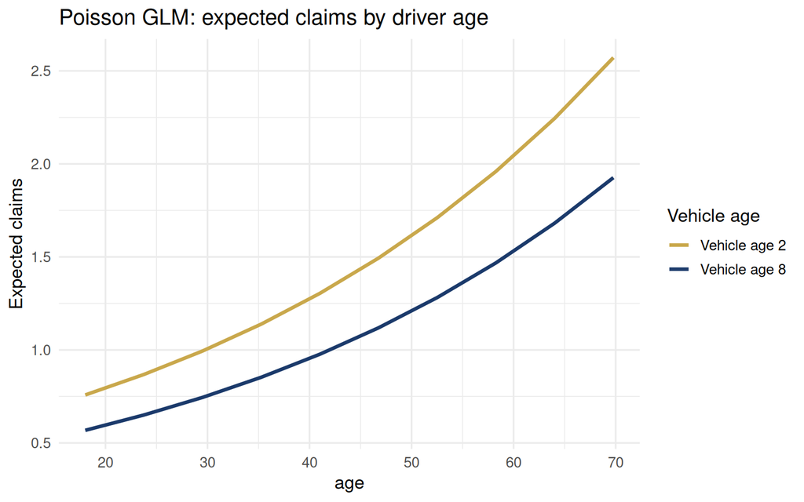

Expected insurance claim counts by driver age, for two vehicle ages. Older vehicles produce fewer expected claims.

```r
claims |>
  data_grid(age = seq_range(age, 10), veh_age = c(2, 8)) |>
  add_predictions(mod_pois, type = "response") |>
  ggplot(aes(age, pred, colour = factor(veh_age))) +
  geom_line(linewidth = 1.2) +
  scale_colour_manual(
    values = c("#C9A84C", "#1B3A6B"),
    labels = c("Vehicle age 2", "Vehicle age 8")
  ) +
  labs(
    y      = "Expected claims",
    title  = "Poisson GLM: expected claims by driver age",
    colour = "Vehicle age"
  ) +
  theme_minimal(base_size = 13)
```

> **Interpretation:** Exponentiated coefficients are **rate ratios**. $e^{0.020} \approx 1.02$ means each additional year of driver age is associated with a 2% increase in expected claims, adjusting for vehicle age.

## 7.4 Robust Linear Models with `MASS::rlm()`

OLS squares residuals, so **outliers inflate the loss disproportionately** and pull the fitted line toward themselves. Robust regression uses a loss function that grows more slowly for large residuals.

**Huber M-estimator (`method = "M"`):**
$$\text{loss}(r) = \begin{cases} r^2/2 & |r|
\leq k \\ k|r| - k^2/2 & |r| > k \end{cases}$$

Large residuals receive *linear* weight rather than *quadratic* weight — their influence is capped.

```r
sim1_out <- sim1_base |>
  mutate(
    y         = ifelse(row_number() %in% c(3, 17), y + 15, y),
    is_outlier = row_number() %in% c(3, 17)
  )

mod_ols <- lm(y ~ x,                     data = sim1_out)
mod_rob <- MASS::rlm(y ~ x, method = "M", data = sim1_out)

cat("OLS:    intercept =", round(coef(mod_ols)[1], 2),
    " slope =", round(coef(mod_ols)[2], 2), "  <- pulled by outliers\n")
```

```
## OLS:    intercept = 6.55  slope = 1.81   <- pulled by outliers
```

```r
cat("Robust: intercept =", round(coef(mod_rob)[1], 2),
    " slope =", round(coef(mod_rob)[2], 2), "  <- close to true values (4.22, 2.05)\n")
```

[output not shown]

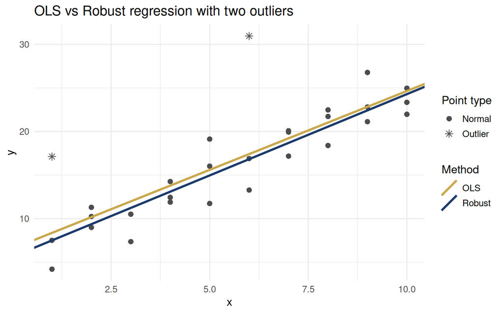

```r
ggplot(sim1_out, aes(x, y, shape = is_outlier)) +
  geom_point(colour = "grey30", size = 2.5) +
  geom_abline(
    aes(intercept = coef(mod_ols)[1], slope = coef(mod_ols)[2],
        colour = "OLS"),    linewidth = 1.2
  ) +
  geom_abline(
    aes(intercept = coef(mod_rob)[1], slope = coef(mod_rob)[2],
        colour = "Robust"), linewidth = 1.2
  ) +
  scale_colour_manual(values = c("OLS" = "#C9A84C", "Robust" = "#1B3A6B")) +
  scale_shape_manual(values  = c(`FALSE` = 16, `TRUE` = 8),
                     labels  = c("Normal", "Outlier"),
                     name    = "Point type") +
  labs(
    title    = "OLS vs Robust regression with two outliers",
    colour   = "Method"
  ) +
  theme_minimal(base_size = 13)
```

## 7.5 Generalised Additive Models with `mgcv::gam()`

GAMs replace each linear predictor term $\beta_j x_j$ with a smooth function $f_j(x_j)$ estimated from the data:

$$y = \beta_0 + f_1(x_1) + f_2(x_2) +
\varepsilon$$

- `s()` specifies a smooth term for a single predictor.
- `te()` specifies a tensor-product smooth for a 2D interaction surface.
- **edf** (effective degrees of freedom): edf ≈ 1 means nearly linear; edf > 3 indicates substantial curvature.
- `method = "REML"` is the preferred criterion for automatic smoothness selection.

```r
mod_gam <- gam(
  y ~ s(x1) + s(x2),
  data   = sim4,
  method = "REML"
)

summary(mod_gam)
```

```
##
## Family: gaussian
## Link function: identity
##
## Formula:
## y ~ s(x1) + s(x2)
##
## Parametric coefficients:
##             Estimate Std. Error t value Pr(>|t|)
## (Intercept)  0.03546    0.12150   0.292    0.771
##
## Approximate significance of smooth terms:
##         edf Ref.df      F p-value
## s(x1) 1.783  2.221  41.97  <2e-16 ***
## s(x2) 1.000  1.000 213.60  <2e-16 ***
## ---
## Signif. codes:  0 '***' 0.001 '**' 0.01 '*' 0.05 '.' 0.1 ' ' 1
##
## R-sq.(adj) =  0.505   Deviance explained =   51%
## -REML = 651.49  Scale est. = 4.4286    n = 300
```

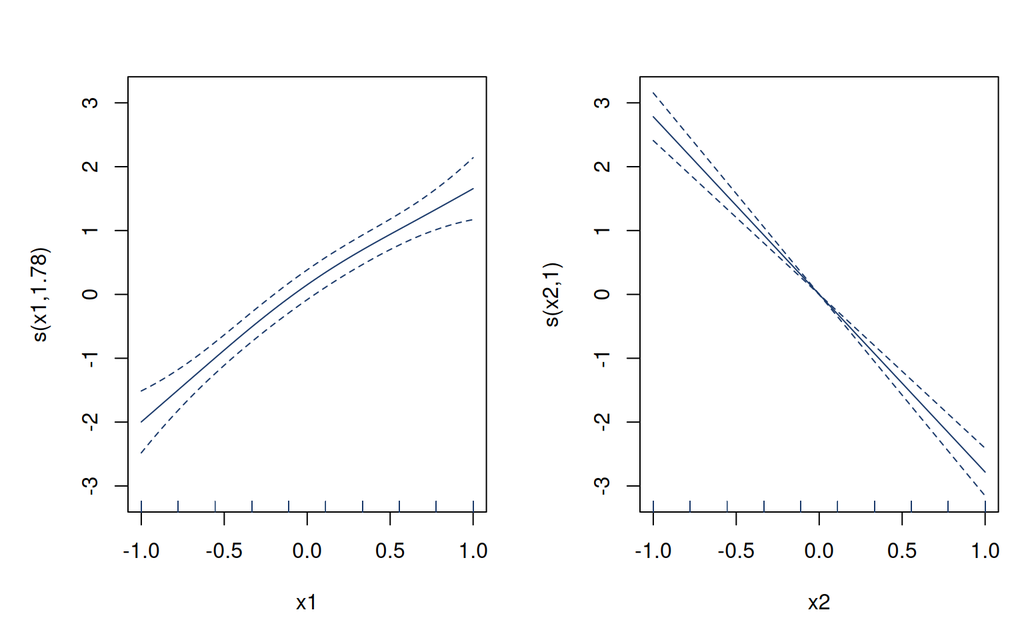

```r
plot(
  mod_gam,
  pages     = 1,
  shade     = TRUE,
  col       = "#1B3A6B",
  shade.col = "#C9A84C40"
)
```

```r
# Tensor-product smooth for a full 2D interaction surface
mod_gam2 <- gam(
  y ~ te(x1, x2),
  data   = sim4,
  method = "REML"
)
```

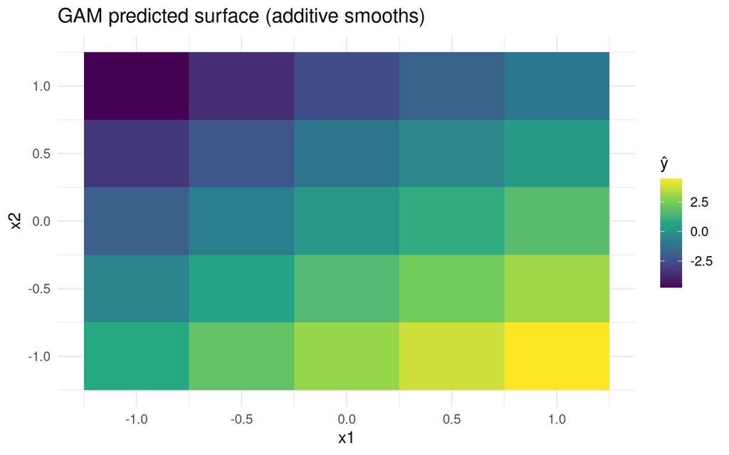

GAM predicted surface (additive smooths on sim4). Colour encodes the predicted response.

```r
grid4 |>
  filter(model == "mod1_s4") |>
  add_predictions(mod_gam, var = "gam_pred") |>
  ggplot(aes(x1, x2, fill = gam_pred)) +
  geom_tile() +
  scale_fill_viridis_c() +
  labs(title = "GAM predicted surface (additive smooths)", fill = "ŷ") +
  theme_minimal(base_size = 13)
```

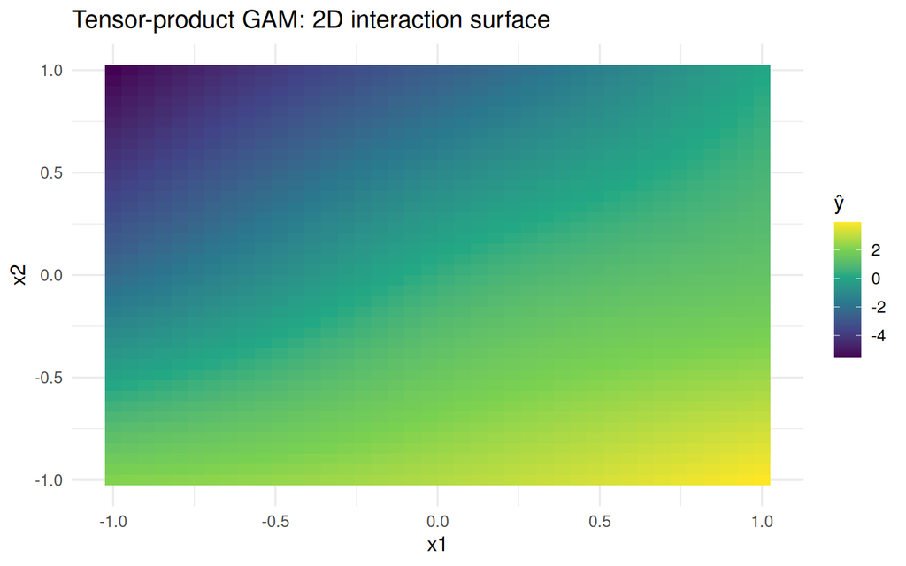

Tensor-product GAM: a single 2D smooth that models the full x1:x2 interaction without assuming additivity.

```r
sim4 |>
  data_grid(
    x1 = seq_range(x1, n = 40),
    x2 = seq_range(x2, n = 40)
  ) |>
  add_predictions(mod_gam2, var = "gam2_pred") |>
  ggplot(aes(x1, x2, fill = gam2_pred)) +
  geom_tile() +
  scale_fill_viridis_c() +
  labs(title = "Tensor-product GAM: 2D interaction surface", fill = "ŷ") +
  theme_minimal(base_size = 13)
```

> **Interpretation:** GAMs estimate the **shape** of each smooth from the data. edf = 1.0 means the smooth is essentially linear; edf > 3 indicates substantial curvature. `method = "REML"` is preferred for smoothness selection because it is less prone to overfitting than maximum likelihood.

## 7.6 Penalised Regression: Ridge and LASSO

When the number of predictors $p$ is large relative to $n$, OLS overfits. Penalised regression adds a penalty on coefficient magnitudes:

$$\hat{\boldsymbol{\beta}}_\lambda =
\arg\min_{\boldsymbol{\beta}} \Bigl[\underbrace{\sum(y_i -
\mathbf{x}_i^\top\boldsymbol{\beta})^2}_{\text{OLS loss}} + \lambda
\cdot
\underbrace{\text{Penalty}(\boldsymbol{\beta})}_{\text{shrinkage}}\Bigr]$$

| Method | Penalty | Effect |
| --- | --- | --- |
| **Ridge** (`alpha = 0`) | $\lambda\sum\beta_j^2$ | Shrinks all coefficients toward zero; keeps all variables |
| **LASSO** (`alpha = 1`) | $\lambda\sum\|\beta_j\|$ | Shrinks some coefficients **exactly to zero**; automatic variable selection |
| **Elastic net** (`0 < alpha < 1`) | Mix of both | Compromise between Ridge and LASSO |

```r
set.seed(2024)
p <- 50; n <- 200
X <- matrix(rnorm(n * p), n, p)
y_pen <- 2 * X[, 1] - 1.5 * X[, 2] + rnorm(n)   # only V1 and V2 matter

mod_ridge <- glmnet::glmnet(X, y_pen, alpha = 0)
mod_lasso <- glmnet::glmnet(X, y_pen, alpha = 1)
```

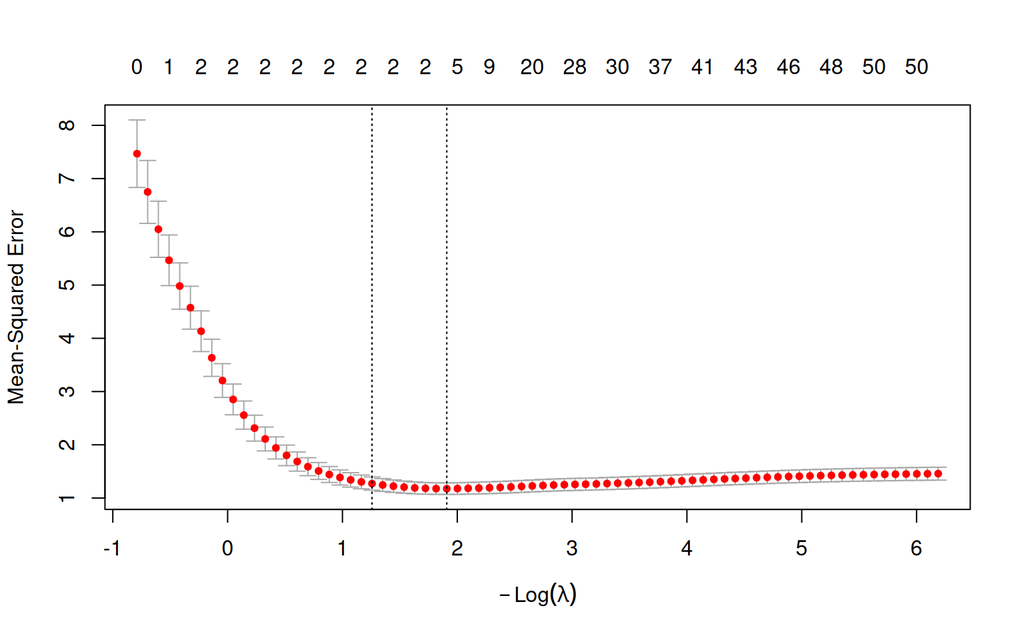

```r
cv_lasso    <- glmnet::cv.glmnet(X, y_pen, alpha = 1, nfolds = 10)
plot(cv_lasso)
```

```r
best_lambda <- cv_lasso$lambda.min
cat("Best lambda:", round(best_lambda, 4), "\n")
```

```
## Best lambda: 0.1483
```

```r
# First 6 coefficients at best lambda — V3+ are shrunk to exactly 0
coef(cv_lasso, s = "lambda.min")[1:6, ]
```

```
## (Intercept)          V1          V2          V3          V4          V5
## -0.05409237  1.92289654 -1.15468193  0.00000000  0.00000000  0.00000000
```

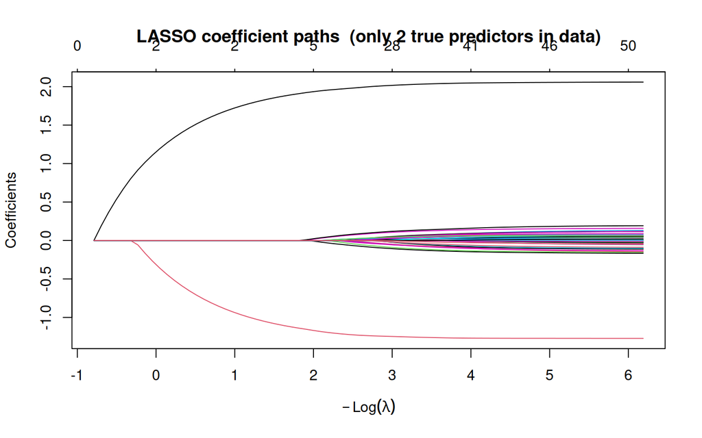

LASSO coefficient paths. As lambda decreases (left to right), more variables enter the model. Only two variables truly matter here.

```r
plot(mod_lasso, xvar = "lambda",
     main = "LASSO coefficient paths  (only 2 true predictors in data)")
abline(v = log(best_lambda), lty = 2, col = "darkred")
```

> **Interpretation:** **Ridge** shrinks all coefficients toward zero but keeps all variables. **LASSO** performs automatic variable selection by setting some coefficients *exactly* to zero. Both are especially useful when $p \gg n$ or predictors are highly correlated. Here, LASSO correctly recovers that only V1 and V2 are the active predictors.

## 7.7 Decision Trees with `rpart`

Decision trees partition the predictor space into **rectangular regions** by recursively splitting on the most informative predictor. Within each leaf node, the prediction is the mean response in that region.

**Key tuning parameters:**

- `maxdepth`: maximum tree depth (controls model complexity).
- `cp` (complexity parameter): prune any split that does not improve the fit by at least `cp × R²`.

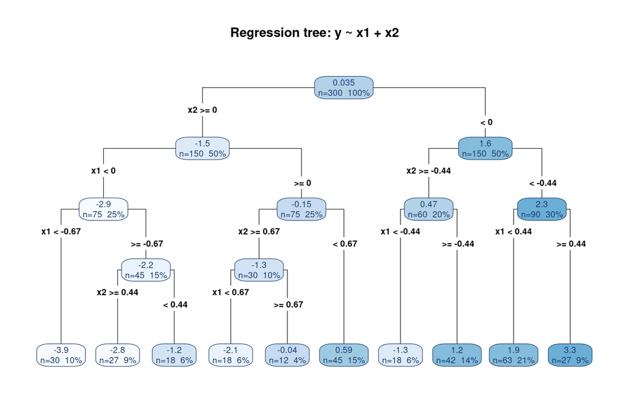

Regression tree for sim4. Each node shows the split rule, predicted value, and percentage of training data.

```r
tree_mod <- rpart(
  y ~ x1 + x2,
  data    = sim4,
  control = rpart.control(maxdepth = 4, cp = 0.01)
)

rpart.plot(
  tree_mod,
  type  = 4,
  extra = 101,
  col   = "#1B3A6B",
  main  = "Regression tree: y ~ x1 + x2"
)
```

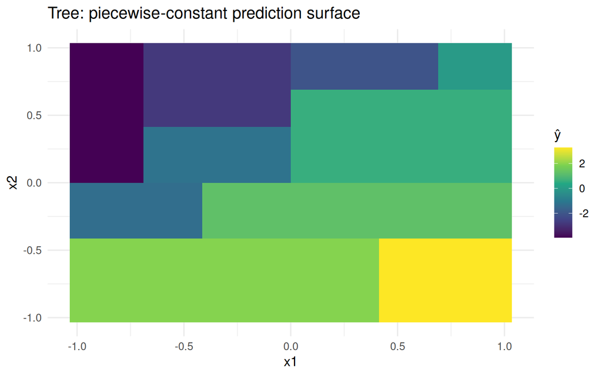

Tree prediction surface: piecewise-constant rectangular regions. Compare with the smooth GAM surface above.

```r
grid4_tree <- sim4 |>
  data_grid(
    x1 = seq_range(x1, 30),
    x2 = seq_range(x2, 30)
  ) |>
  add_predictions(tree_mod)

ggplot(grid4_tree, aes(x1, x2, fill = pred)) +
  geom_tile() +
  scale_fill_viridis_c() +
  labs(title = "Tree: piecewise-constant prediction surface", fill = "ŷ") +
  theme_minimal(base_size = 13)
```

> **Interpretation:** Trees partition the predictor space into **rectangular regions**, predicting the mean response within each region. The prediction surface is **step-wise** — visible as hard edges in the tile plot. Trees are highly interpretable but have high variance; ensemble methods (Random Forest, XGBoost) fix this by averaging many trees.